# Udacity Problem Set 3

William W. Chiang

December 25, 2015

# Lesson 3

### Diamonds Data

Notes: Prices of 50,000 round cut diamonds

Description

A dataset containing the prices and other attributes of almost 54,000 diamonds. The variables are as follows:

Usage

data(diamonds) Format

A data frame with 53940 rows and 10 variables

Details

price. price in US dollars ($326–$18,823)

carat. weight of the diamond (0.2–5.01)

cut. quality of the cut (Fair, Good, Very Good, Premium, Ideal)

colour. diamond colour, from J (worst) to D (best)

clarity. a measurement of how clear the diamond is (I1 (worst), SI1, SI2, VS1, VS2, VVS1, VVS2, IF (best))

depth. total depth percentage = z / mean(x, y) = 2 * z / (x + y) (43–79)

table. width of top of diamond relative to widest point (43–95)

## 1

Load ggplot2 package and ‘diamonds’ data set and print summary

```r
library(ggplot2)
data(diamonds)
summary(diamonds)
```

```
##      carat               cut        color        clarity
##  Min.   :0.2000   Fair     : 1610   D: 6775   SI1    :13065
##  1st Qu.:0.4000   Good     : 4906   E: 9797   VS2    :12258
##  Median :0.7000   Very Good:12082   F: 9542   SI2    : 9194
##  Mean   :0.7979   Premium  :13791   G:11292   VS1    : 8171
##  3rd Qu.:1.0400   Ideal    :21551   H: 8304   VVS2   : 5066
##  Max.   :5.0100                     I: 5422   VVS1   : 3655
##                                     J: 2808   (Other): 2531
##      depth           table           price             x
##  Min.   :43.00   Min.   :43.00   Min.   :  326   Min.   : 0.000
##  1st Qu.:61.00   1st Qu.:56.00   1st Qu.:  950   1st Qu.: 4.710
##  Median :61.80   Median :57.00   Median : 2401   Median : 5.700
##  Mean   :61.75   Mean   :57.46   Mean   : 3933   Mean   : 5.731
##  3rd Qu.:62.50   3rd Qu.:59.00   3rd Qu.: 5324   3rd Qu.: 6.540
##  Max.   :79.00   Max.   :95.00   Max.   :18823   Max.   :10.740
##
##        y                z
##  Min.   : 0.000   Min.   : 0.000
##  1st Qu.: 4.720   1st Qu.: 2.910
##  Median : 5.710   Median : 3.530
##  Mean   : 5.735   Mean   : 3.539
##  3rd Qu.: 6.540   3rd Qu.: 4.040
##  Max.   :58.900   Max.   :31.800
##
```

## 2

Create a histogram of the price of all the diamonds in the diamond data set

```
## stat_bin: binwidth defaulted to range/30. Use 'binwidth = x' to adjust this.
```

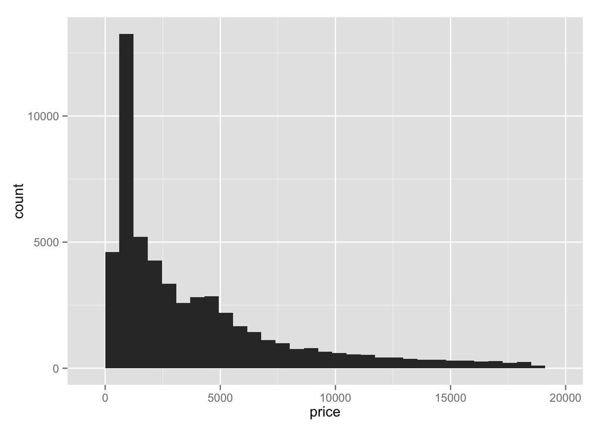

```r
qplot(x = price, data = diamonds)
```

Shape is right-skewed

```r
summary(diamonds$price)
```

```
##    Min. 1st Qu.  Median    Mean 3rd Qu.    Max.
##     326     950    2401    3933    5324   18820
```

Mean (3933) is more on the right than the median (2401)

## 3

# Number of diamonds costing less than $500

```r
dim(subset(diamonds, price < 500))
```

```
## [1] 1729   10
```

# Number of diamonds costing less than $250

```r
dim(subset(diamonds, price < 250))
```

```
## [1]  0 10
```

# Number of diamonds costing $15,000 *or* more

```r
dim(subset(diamonds, price >= 15000))
```

```
## [1] 1656   10
```

## 4

# Explore the largest peak in the price histogram

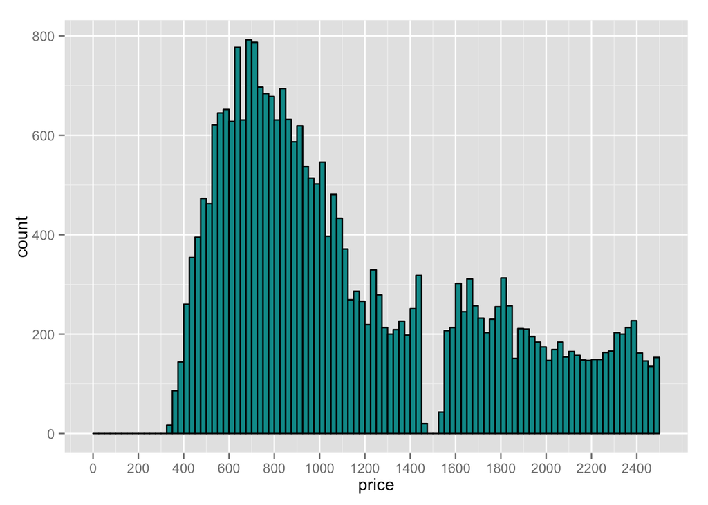

```r
qplot(x = price, data = diamonds, color = I('black'), fill = I('#009999'), binwidth = 25) +
  scale_x_continuous(limits= c(0,2500), breaks = seq(0,2400,200))
```

Most common price of diamond is in the range of $600 - $800

## 5

# Break out the histogram of diamond prices by cut

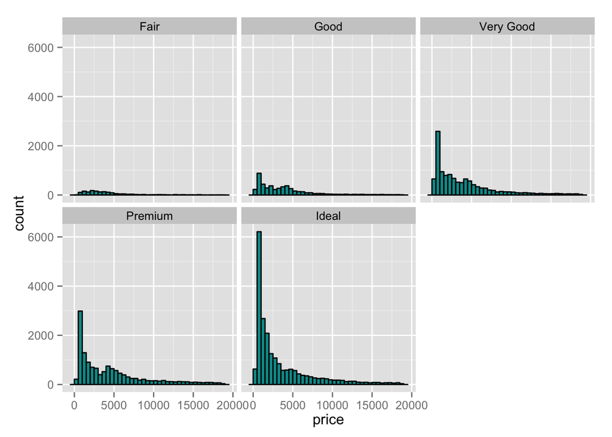

```r
qplot(x = price, data = diamonds, color = I('black'), fill = I('#009999'), binwidth = 500) +
  facet_wrap(~cut)
```

Determine which cut has (1) the highest priced diamond, (2) the lowest priced diamond, and (3) the lowest median price

```r
by(diamonds$price,diamonds$cut,summary, digits = max(getOption('digits')))
```

```
## diamonds$cut: Fair
##      Min.   1st Qu.    Median      Mean   3rd Qu.      Max.
##   337.000  2050.250  3282.000  4358.758  5205.500 18574.000
## --------------------------------------------------------
## diamonds$cut: Good
##      Min.   1st Qu.    Median      Mean   3rd Qu.      Max.
##   327.000  1145.000  3050.500  3928.864  5028.000 18788.000
## --------------------------------------------------------
## diamonds$cut: Very Good
##     Min.  1st Qu.   Median     Mean  3rd Qu.     Max.
##   336.00   912.00  2648.00  3981.76  5372.75 18818.00
## --------------------------------------------------------
## diamonds$cut: Premium
##      Min.   1st Qu.    Median      Mean   3rd Qu.      Max.
##   326.000  1046.000  3185.000  4584.258  6296.000 18823.000
## --------------------------------------------------------
## diamonds$cut: Ideal
##      Min.   1st Qu.    Median      Mean   3rd Qu.      Max.
##   326.000   878.000  1810.000  3457.542  4678.500 18806.000
```

## 6

Like the previous qplot code but with added facet_wrap parameter implemented so that the y-axis in the histogram is not fixed

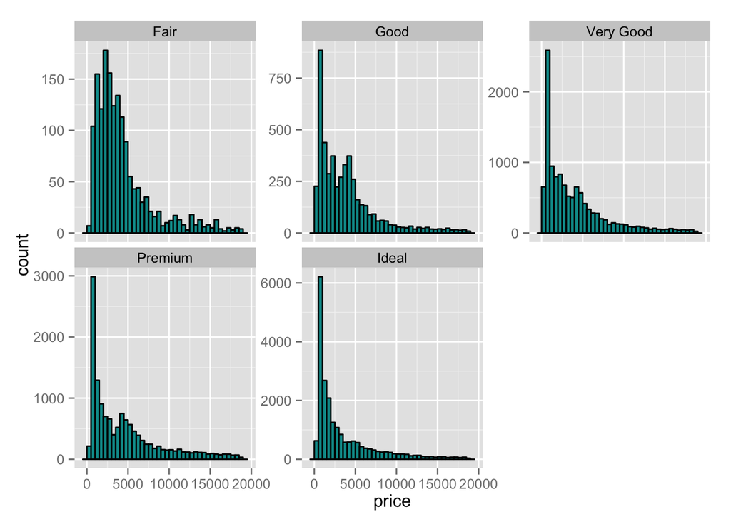

```r
qplot(x = price, data = diamonds, color = I('black'), fill = I('#009999'), binwidth = 500) +
  facet_wrap(~cut, scales = "free_y")
```

***

## 7

### Create a histogram of price per carat and facet it by cut

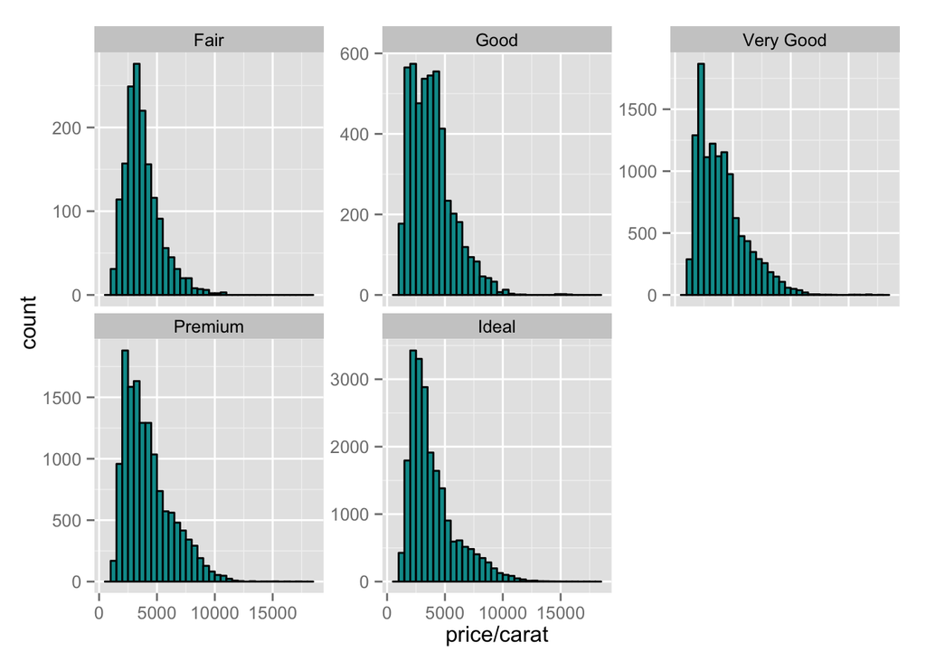

```r
qplot(x = price/carat, data = diamonds, color = I('black'), fill = I('#009999'), binwidth = 500) +
  facet_wrap(~cut, scales = "free_y")
```

### Adjust the bin width and transform the scale of the x-axis using log10

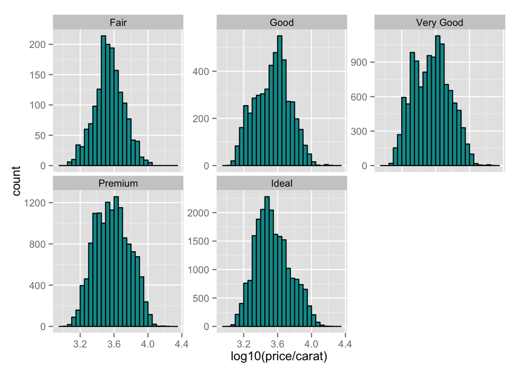

```r
qplot(x = log10(price/carat), data = diamonds, color = I('black'), fill = I('#009999'), binwidth = 0.05) +
  facet_wrap(~cut, scales = "free_y")
```

***

## 8

### Investigate the price of diamonds using box plots, numerical summaries, and one of the following categorical variables: cut, clarity, or color

## BOX PLOT - by cut

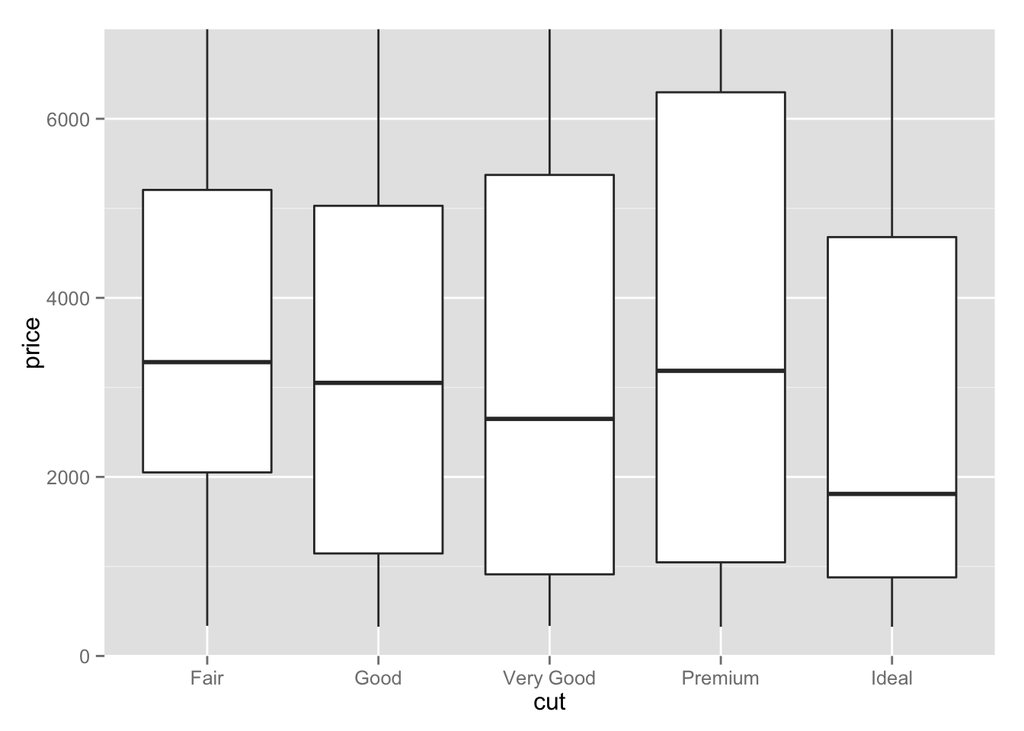

```r
qplot(x = cut, y = price, data = diamonds, geom = "boxplot") +
  coord_cartesian(ylim = c(0, 7000))
```

## BOX PLOT - by clarity

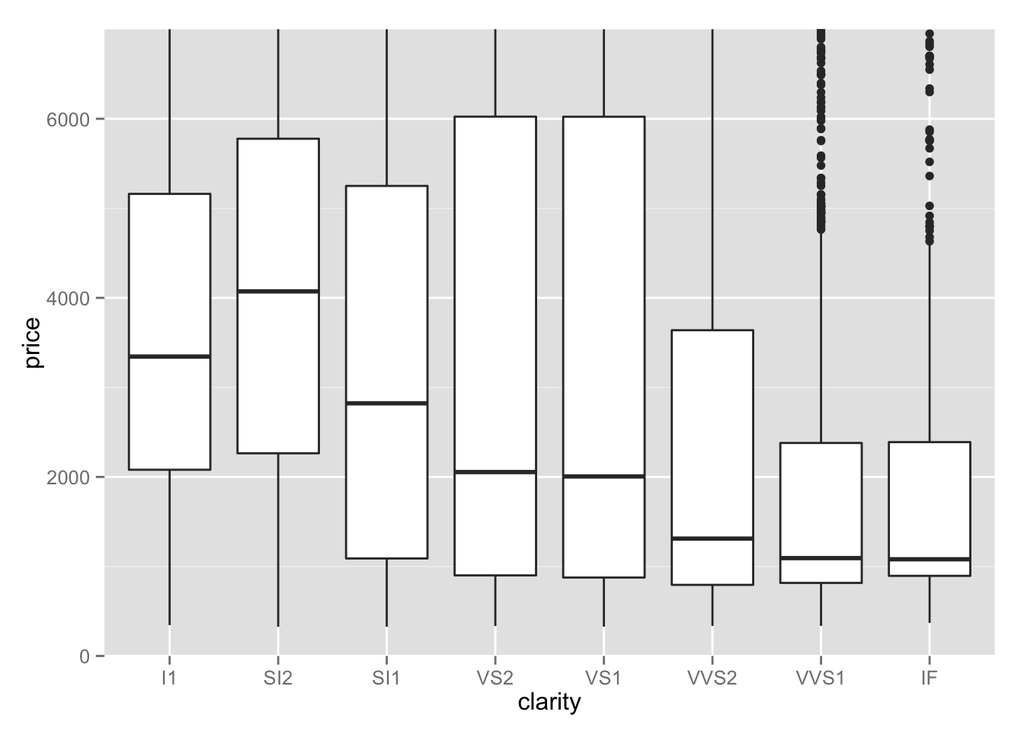

```r
qplot(x = clarity, y = price, data = diamonds, geom = "boxplot") +
  coord_cartesian(ylim = c(0, 7000))
```

## BOX PLOT - by color

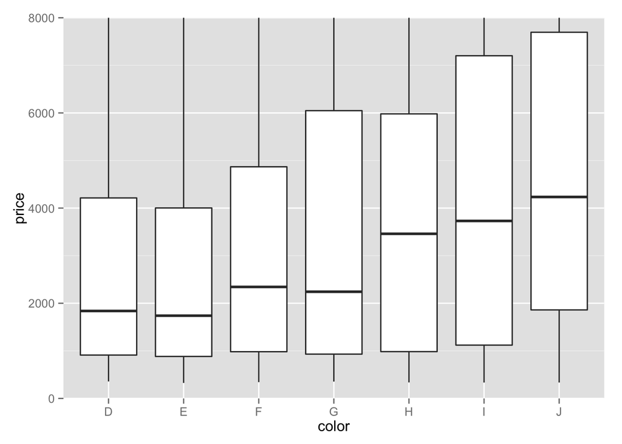

```r
qplot(x = color, y = price, data = diamonds, geom = "boxplot") +
  coord_cartesian(ylim = c(0, 8000))
```

## Numerical summaries

```r
by(diamonds$price, diamonds$color, summary)
```

```
## diamonds$color: D
##    Min. 1st Qu.  Median    Mean 3rd Qu.    Max.
##     357     911    1838    3170    4214   18690
## --------------------------------------------------------
## diamonds$color: E
##    Min. 1st Qu.  Median    Mean 3rd Qu.    Max.
##     326     882    1739    3077    4003   18730
## --------------------------------------------------------
## diamonds$color: F
##    Min. 1st Qu.  Median    Mean 3rd Qu.    Max.
##     342     982    2344    3725    4868   18790
## --------------------------------------------------------
## diamonds$color: G
##    Min. 1st Qu.  Median    Mean 3rd Qu.    Max.
##     354     931    2242    3999    6048   18820
## --------------------------------------------------------
## diamonds$color: H
##    Min. 1st Qu.  Median    Mean 3rd Qu.    Max.
##     337     984    3460    4487    5980   18800
## --------------------------------------------------------
## diamonds$color: I
##    Min. 1st Qu.  Median    Mean 3rd Qu.    Max.
##     334    1120    3730    5092    7202   18820
## --------------------------------------------------------
## diamonds$color: J
##    Min. 1st Qu.  Median    Mean 3rd Qu.    Max.
##     335    1860    4234    5324    7695   18710
```

## 9

# Boxplot illustrating the price per carat of diamonds across the different colors of diamonds

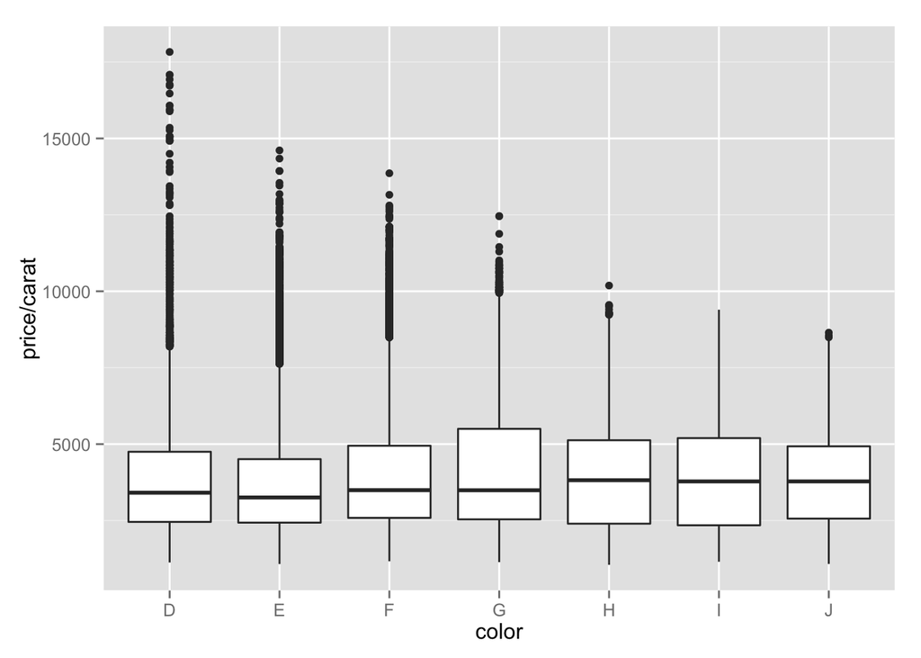

```r
qplot(x = color, y = price/carat, data = diamonds, geom = "boxplot")
```

## 10

### Illustration of a frequencies polygon according to carats of diamonds

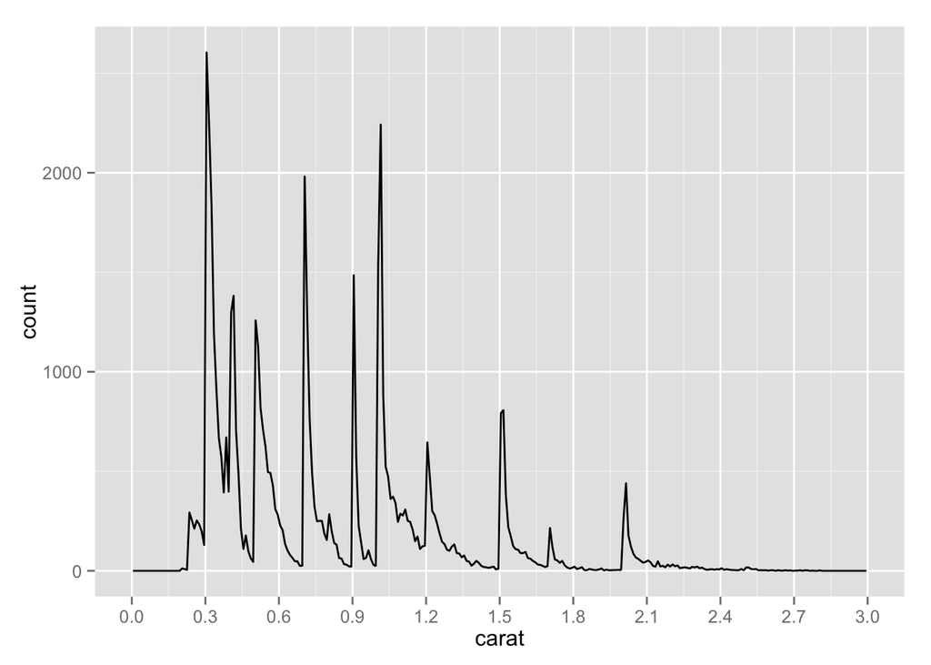

```r
qplot(x = carat,
      data = diamonds,
      binwidth = 0.01,
      geom = 'freqpoly') +
  scale_x_continuous(lim = c(0,3), breaks = seq(0,3,0.3))
```